# FinalReport Inferential Statistics

Tomoya Kubo

## Background Information

In a Stroop task, participants are presented with a list of words, with each word displayed in a color of ink. The participant’s task is to say out loud the color of the ink in which the word is printed. The task has two conditions: a congruent words condition, and an incongruent words condition. In the congruent words condition, the words being displayed are color words whose names match the colors in which they are printed: for example RED, BLUE. In the incongruent words condition, the words displayed are color words whose names do not match the colors in which they are printed: for example PURPLE, ORANGE. In each case, we measure the time it takes to name the ink colors in equally-sized lists. Each participant will go through and record a time from each condition.

## Report Content

I’m going to try investigation about stroop task result. Get the data, and check the variable. Finally, I’m going to do statical test and report it.

#### About data

The dataset is from following Udacity’s link. https://drive.google.com/file/d/0B9Yf01UaIbUgQXpYb2NhZ29yX1U/view

The dataset include 2 variables that are time on congruent word condition and time on Incongruent word condition. These have 24 values.

#### Import dataset

```r
data <- read.csv("stroopdata.csv")
data
```

```
##    Congruent Incongruent
## 1     12.079      19.278
## 2     16.791      18.741
## 3      9.564      21.214
## 4      8.630      15.687
## 5     14.669      22.803
## 6     12.238      20.878
## 7     14.692      24.572
## 8      8.987      17.394
## 9      9.401      20.762
## 10    14.480      26.282
## 11    22.328      24.524
## 12    15.298      18.644
## 13    15.073      17.510
## 14    16.929      20.330
## 15    18.200      35.255
## 16    12.130      22.158
## 17    18.495      25.139
## 18    10.639      20.429
## 19    11.344      17.425
## 20    12.369      34.288
## 21    12.944      23.894
## 22    14.233      17.960
## 23    19.710      22.058
## 24    16.004      21.157
```

## Question and Answer

#### 1. What is our independent variable? What is our dependent variable?

- independent : congruent words condition
- dependent : time

#### 2. What is an appropriate set of hypotheses for this task? What kind of statistical test do you expect to perform? Justify your choices.

##### Hypotheses

- μ1:Population mean of response time on congruent word condition
- μ2:Population mean of response time on incongruent word condition
- H0: μ1 = μ2 (There is no significant difference in response time for the population to state the colors in a congruent or incongruent condition.)
- H1: μ1 != μ2 (There is significant difference in response time for the population to state the colors in a congruent or incongruent condition.)

##### Statistical test

This stroop task is dependent test for paired samples, that each participant will go through and record a time from each condition. And we can get data with 24 samples each on each condition that is sampling distribution. we don’t know population parameter that are mean and standard deviation. Therefore, I’ll do t-test.The task process is following.

1. Create Null and Alternative Hypothesis
2. t-statics
3. Make statistical decision

#### 3. Report some descriptive statistics regarding this dataset. Include at least one measure of central tendency and at least one measure of variability.

##### Point estimate

###### Sample Mean

```r
Mean_Congruent <- sum(data$Congruent)/length(data$Congruent)
Mean_Incongruent <- sum(data$Incongruent)/length(data$Incongruent)
print(paste("Congruent",Mean_Congruent,sep=":"))
```

```
## [1] "Congruent:14.051125"
```

```r
print(paste("Incongruent",Mean_Incongruent,sep=":"))
```

```
## [1] "Incongruent:22.0159166666667"
```

```r
sd_Congruent <- sqrt(sum((data$Congruent - Mean_Congruent)^2) / (length(data$Congruent)-1))
sd_Incongruent <- sqrt(sum((data$Incongruent - Mean_Incongruent)^2) / (length(data$Incongruent)-1))
print(paste("Congruent",sd_Congruent,sep=":"))
```

```
## [1] "Congruent:3.5593579576452"
```

```r
print(paste("Incongruent",sd_Incongruent,sep=":"))
```

```
## [1] "Incongruent:4.79705712246914"
```

#### 4. Provide one or two visualizations that show the distribution of the sample data. Write one or two sentences noting what you observe about the plot or plots.

###### I’m create boxplot for understanding the difference of distribution between each condition.

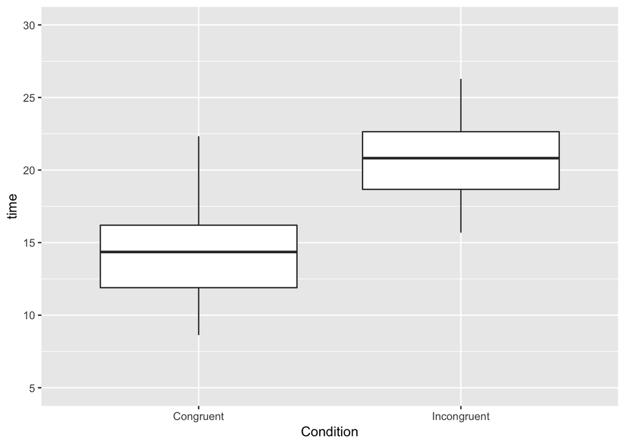

```r
library("ggplot2")
library(reshape2)
data_long <- melt(as.matrix(data))[,2:3]
names(data_long) <- c("Condition", "time")
ggplot(data=data_long, aes(x=Condition, y=time))+
  geom_boxplot()+
  scale_y_continuous(breaks=seq(5,30,5), limits=c(5,30))
```

The difference between each condition is big. Congruent’s 3rd quantile is smaller than Incongruent’s 1st quantile.

#### 5. Now, perform the statistical test and report your results. What is your confidence level and your critical statistic value? Do you reject the null hypothesis or fail to reject it? Come to a conclusion in terms of the experiment task. Did the results match up with your expectations?

##### I’m going to do t-test.

##### (1)Point Estimate

```r
myu_congruent <- mean(data$Congruent)
myu_incongruent <- mean(data$Incongruent)
data$con_incon <- data$Congruent - data$Incongruent
point_estimate <- myu_congruent - myu_incongruent

print(paste("μ_congruent",myu_congruent,sep=":"))
```

```
## [1] "μ_congruent:14.051125"
```

```r
print(paste("μ_incongruent",myu_incongruent,sep=":"))
```

```
## [1] "μ_incongruent:22.0159166666667"
```

```r
print(paste("point_estimate",point_estimate,sep=":"))
```

```
## [1] "point_estimate:-7.96479166666666"
```

##### (2)t_statics

```r
n <- length(data$con_incon)
df <- n - 1
s <- sqrt(sum((data$con_incon-point_estimate)^2)/(df))
t_value <- point_estimate / s * sqrt(n)
print(paste("data_num",n,sep=":"))
```

```
## [1] "data_num:24"
```

```r
print(paste("df",df,sep=":"))
```

```
## [1] "df:23"
```

```r
print(paste("t_statistic",t_value,sep=":"))
```

```
## [1] "t_statistic:-8.02070694410996"
```

##### (3)critical statistic value

```r
print(paste("df",df,sep=":"))
```

```
## [1] "df:23"
```

##### 2 tail test

##### α:0.05

##### t_critical:+-2.069

##### I regect the null hypothesis. because t-value(-8.02) is smaller than t_critical(-2.069).

#### 6. Optional: What do you think is responsible for the effects observed? Can you think of an alternative or similar task that would result in a similar effect? Some research about the problem will be helpful for thinking about these two questions!

##### I think this result is related association transformation.If people say color name that they saw color of objects,they need to translate visual information to language information. The process need longer time compared with direct reading that they read the written object name.

##### I think of an similar task that vehicle name test.People say vehicle’s name when they saw vehicle’s pictures.Pictures include congruent and incongruent vehicle’s name.

#### Reference

- Background : https://docs.google.com/document/d/1-OkpZLjG_kX9J6LIQ5IltsqMzVWjh36QpnP2RYpVdPU/pub?embedded=True
- Dataset : https://drive.google.com/file/d/0B9Yf01UaIbUgQXpYb2NhZ29yX1U/view
- t-table : https://s3.amazonaws.com/udacity-hosted-downloads/t-table.jp